# Risk Factor Analysis

## Outcome Variable

**Outcome Variable:** ever_co

## Predictor Variables

**Intervention Variable:** perdiar24

**Adjustment Set:**

- arm
- sex
- W_mage
- meducyrs
- feducyrs
- hhwealth_quart
- hfoodsec
- hdlvry
- W_birthwt
- W_birthlen
- single
- W_nrooms
- month
- brthmon
- impfloor
- impsan
- safeh20
- delta_W_mage
- delta_meducyrs
- delta_feducyrs
- delta_hhwealth_quart
- delta_hfoodsec
- delta_hdlvry
- delta_W_birthwt
- delta_W_birthlen
- delta_single
- delta_W_nrooms
- delta_month
- delta_brthmon
- delta_impfloor
- delta_impsan
- delta_safeh20

## Stratifying Variables

The analysis was stratified on these variable(s):

- agecat
- studyid
- country

## Data Summary

| agecat | studyid | country | perdiar24 | ever_co | n_cell | n |
| --- | --- | --- | --- | --- | --- | --- |
| 0-24 months | CMIN | BANGLADESH | 0% | 0 | 10 | 271 |
| 0-24 months | CMIN | BANGLADESH | 0% | 1 | 0 | 271 |
| 0-24 months | CMIN | BANGLADESH | (0%, 5%] | 0 | 75 | 271 |
| 0-24 months | CMIN | BANGLADESH | (0%, 5%] | 1 | 46 | 271 |
| 0-24 months | CMIN | BANGLADESH | >5% | 0 | 94 | 271 |
| 0-24 months | CMIN | BANGLADESH | >5% | 1 | 46 | 271 |
| 0-24 months | CONTENT | PERU | 0% | 0 | 6 | 215 |
| 0-24 months | CONTENT | PERU | 0% | 1 | 0 | 215 |
| 0-24 months | CONTENT | PERU | (0%, 5%] | 0 | 142 | 215 |
| 0-24 months | CONTENT | PERU | (0%, 5%] | 1 | 0 | 215 |
| 0-24 months | CONTENT | PERU | >5% | 0 | 67 | 215 |
| 0-24 months | CONTENT | PERU | >5% | 1 | 0 | 215 |
| 0-24 months | EE | PAKISTAN | 0% | 0 | 141 | 379 |
| 0-24 months | EE | PAKISTAN | 0% | 1 | 120 | 379 |
| 0-24 months | EE | PAKISTAN | (0%, 5%] | 0 | 68 | 379 |
| 0-24 months | EE | PAKISTAN | (0%, 5%] | 1 | 50 | 379 |
| 0-24 months | EE | PAKISTAN | >5% | 0 | 0 | 379 |
| 0-24 months | EE | PAKISTAN | >5% | 1 | 0 | 379 |
| 0-24 months | Guatemala BSC | GUATEMALA | 0% | 0 | 31 | 309 |
| 0-24 months | Guatemala BSC | GUATEMALA | 0% | 1 | 2 | 309 |
| 0-24 months | Guatemala BSC | GUATEMALA | (0%, 5%] | 0 | 64 | 309 |
| 0-24 months | Guatemala BSC | GUATEMALA | (0%, 5%] | 1 | 7 | 309 |
| 0-24 months | Guatemala BSC | GUATEMALA | >5% | 0 | 191 | 309 |
| 0-24 months | Guatemala BSC | GUATEMALA | >5% | 1 | 14 | 309 |
| 0-24 months | iLiNS-Zinc | BURKINA FASO | 0% | 0 | 309 | 2449 |
| 0-24 months | iLiNS-Zinc | BURKINA FASO | 0% | 1 | 48 | 2449 |
| 0-24 months | iLiNS-Zinc | BURKINA FASO | (0%, 5%] | 0 | 1170 | 2449 |
| 0-24 months | iLiNS-Zinc | BURKINA FASO | (0%, 5%] | 1 | 154 | 2449 |
| 0-24 months | iLiNS-Zinc | BURKINA FASO | >5% | 0 | 671 | 2449 |
| 0-24 months | iLiNS-Zinc | BURKINA FASO | >5% | 1 | 97 | 2449 |

[output cut: 270 more lines]

The following strata were considered:

- agecat: 0-24 months, studyid: CMIN, country: BANGLADESH
- agecat: 0-24 months, studyid: CONTENT, country: PERU
- agecat: 0-24 months, studyid: EE, country: PAKISTAN
- agecat: 0-24 months, studyid: Guatemala BSC, country: GUATEMALA
- agecat: 0-24 months, studyid: iLiNS-Zinc, country: BURKINA FASO
- agecat: 0-24 months, studyid: JiVitA-4, country: BANGLADESH
- agecat: 0-24 months, studyid: MAL-ED, country: BANGLADESH
- agecat: 0-24 months, studyid: MAL-ED, country: BRAZIL
- agecat: 0-24 months, studyid: MAL-ED, country: INDIA
- agecat: 0-24 months, studyid: MAL-ED, country: NEPAL
- agecat: 0-24 months, studyid: MAL-ED, country: PERU
- agecat: 0-24 months, studyid: MAL-ED, country: SOUTH AFRICA
- agecat: 0-24 months, studyid: MAL-ED, country: TANZANIA, UNITED REPUBLIC OF
- agecat: 0-24 months, studyid: NIH-Birth, country: BANGLADESH
- agecat: 0-24 months, studyid: NIH-Crypto, country: BANGLADESH
- agecat: 0-24 months, studyid: PROVIDE, country: BANGLADESH
- agecat: 0-24 months, studyid: SAS-FoodSuppl, country: INDIA
- agecat: 0-6 months, studyid: CMIN, country: BANGLADESH
- agecat: 0-6 months, studyid: CONTENT, country: PERU
- agecat: 0-6 months, studyid: EE, country: PAKISTAN
- agecat: 0-6 months, studyid: Guatemala BSC, country: GUATEMALA
- agecat: 0-6 months, studyid: JiVitA-4, country: BANGLADESH
- agecat: 0-6 months, studyid: MAL-ED, country: BANGLADESH
- agecat: 0-6 months, studyid: MAL-ED, country: BRAZIL
- agecat: 0-6 months, studyid: MAL-ED, country: INDIA
- agecat: 0-6 months, studyid: MAL-ED, country: NEPAL
- agecat: 0-6 months, studyid: MAL-ED, country: PERU
- agecat: 0-6 months, studyid: MAL-ED, country: SOUTH AFRICA
- agecat: 0-6 months, studyid: MAL-ED, country: TANZANIA, UNITED REPUBLIC OF
- agecat: 0-6 months, studyid: NIH-Birth, country: BANGLADESH
- agecat: 0-6 months, studyid: NIH-Crypto, country: BANGLADESH
- agecat: 0-6 months, studyid: PROVIDE, country: BANGLADESH
- agecat: 0-6 months, studyid: SAS-FoodSuppl, country: INDIA
- agecat: 6-24 months, studyid: CMIN, country: BANGLADESH
- agecat: 6-24 months, studyid: CONTENT, country: PERU
- agecat: 6-24 months, studyid: EE, country: PAKISTAN
- agecat: 6-24 months, studyid: Guatemala BSC, country: GUATEMALA
- agecat: 6-24 months, studyid: iLiNS-Zinc, country: BURKINA FASO
- agecat: 6-24 months, studyid: JiVitA-4, country: BANGLADESH
- agecat: 6-24 months, studyid: MAL-ED, country: BANGLADESH
- agecat: 6-24 months, studyid: MAL-ED, country: BRAZIL
- agecat: 6-24 months, studyid: MAL-ED, country: INDIA
- agecat: 6-24 months, studyid: MAL-ED, country: NEPAL
- agecat: 6-24 months, studyid: MAL-ED, country: PERU
- agecat: 6-24 months, studyid: MAL-ED, country: SOUTH AFRICA
- agecat: 6-24 months, studyid: MAL-ED, country: TANZANIA, UNITED REPUBLIC OF
- agecat: 6-24 months, studyid: NIH-Birth, country: BANGLADESH
- agecat: 6-24 months, studyid: NIH-Crypto, country: BANGLADESH
- agecat: 6-24 months, studyid: PROVIDE, country: BANGLADESH
- agecat: 6-24 months, studyid: SAS-FoodSuppl, country: INDIA

### Dropped Strata

Some strata were dropped due to rare outcomes:

- agecat: 0-24 months, studyid: CMIN, country: BANGLADESH
- agecat: 0-24 months, studyid: CONTENT, country: PERU
- agecat: 0-24 months, studyid: EE, country: PAKISTAN
- agecat: 0-24 months, studyid: Guatemala BSC, country: GUATEMALA
- agecat: 0-24 months, studyid: MAL-ED, country: BANGLADESH
- agecat: 0-24 months, studyid: MAL-ED, country: BRAZIL
- agecat: 0-24 months, studyid: MAL-ED, country: INDIA
- agecat: 0-24 months, studyid: MAL-ED, country: NEPAL
- agecat: 0-24 months, studyid: MAL-ED, country: PERU
- agecat: 0-24 months, studyid: MAL-ED, country: SOUTH AFRICA
- agecat: 0-24 months, studyid: MAL-ED, country: TANZANIA, UNITED REPUBLIC OF
- agecat: 0-24 months, studyid: NIH-Birth, country: BANGLADESH
- agecat: 0-24 months, studyid: PROVIDE, country: BANGLADESH
- agecat: 0-6 months, studyid: CMIN, country: BANGLADESH
- agecat: 0-6 months, studyid: CONTENT, country: PERU
- agecat: 0-6 months, studyid: EE, country: PAKISTAN
- agecat: 0-6 months, studyid: Guatemala BSC, country: GUATEMALA
- agecat: 0-6 months, studyid: MAL-ED, country: BANGLADESH
- agecat: 0-6 months, studyid: MAL-ED, country: BRAZIL
- agecat: 0-6 months, studyid: MAL-ED, country: INDIA
- agecat: 0-6 months, studyid: MAL-ED, country: NEPAL
- agecat: 0-6 months, studyid: MAL-ED, country: PERU
- agecat: 0-6 months, studyid: MAL-ED, country: SOUTH AFRICA
- agecat: 0-6 months, studyid: MAL-ED, country: TANZANIA, UNITED REPUBLIC OF
- agecat: 0-6 months, studyid: NIH-Birth, country: BANGLADESH
- agecat: 0-6 months, studyid: NIH-Crypto, country: BANGLADESH
- agecat: 0-6 months, studyid: PROVIDE, country: BANGLADESH
- agecat: 6-24 months, studyid: CMIN, country: BANGLADESH
- agecat: 6-24 months, studyid: CONTENT, country: PERU
- agecat: 6-24 months, studyid: EE, country: PAKISTAN
- agecat: 6-24 months, studyid: Guatemala BSC, country: GUATEMALA
- agecat: 6-24 months, studyid: MAL-ED, country: BANGLADESH
- agecat: 6-24 months, studyid: MAL-ED, country: BRAZIL
- agecat: 6-24 months, studyid: MAL-ED, country: INDIA
- agecat: 6-24 months, studyid: MAL-ED, country: NEPAL
- agecat: 6-24 months, studyid: MAL-ED, country: PERU
- agecat: 6-24 months, studyid: MAL-ED, country: SOUTH AFRICA
- agecat: 6-24 months, studyid: MAL-ED, country: TANZANIA, UNITED REPUBLIC OF
- agecat: 6-24 months, studyid: NIH-Birth, country: BANGLADESH
- agecat: 6-24 months, studyid: PROVIDE, country: BANGLADESH

## Methods Detail

We’re interested in the causal parameters $E[Y_a]$ for all values of $a \in \mathcal{A}$. These parameters represent the mean outcome if, possibly contrary to fact, we intervened to set all units to have $A=a$. Under the randomization and positivity assumptions, these are identified by the statistical parameters $\psi_a=E_W[E_{Y|A,W}(Y|A=a,W)]$. In addition, we’re interested in the mean of $Y$, $E[Y]$ under no intervention (the observed mean). We will estimate these parameters by using SuperLearner to fit the relevant likelihood factors – $E_{Y|A,W}(Y|A=a,W)$ and $p(A=a|W)$, and then updating our likelihood fit using a joint TMLE.

For unadjusted analyses ($W=\{\}$), initial likelihoods were estimated using Lrnr_glm to estimate the simple $E(Y|A)$ and Lrnr_mean to estimate $p(A)$. For adjusted analyses, a small library containing Lrnr_glmnet, Lrnr_xgboost, and Lrnr_mean was used.

Having estimated these parameters, we will then use the delta method to estimate relative risks and attributable risks relative to a prespecified baseline level of $A$.

# Results Detail

## Results Plots

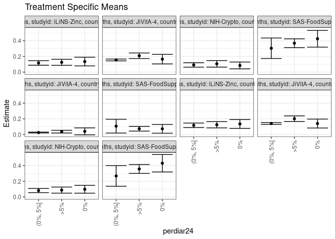

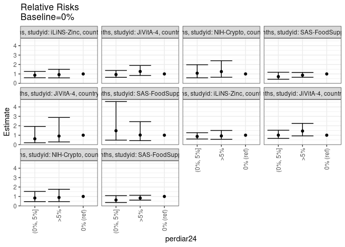

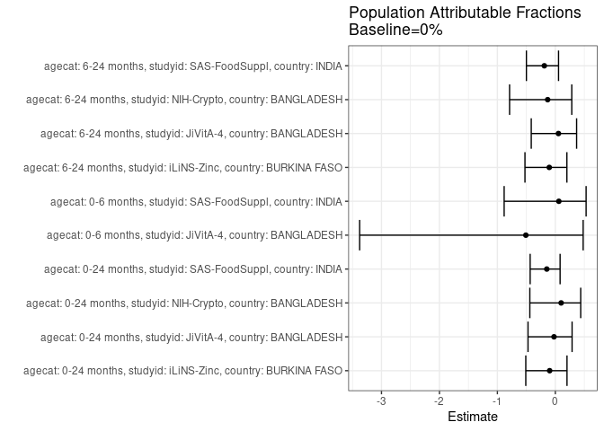

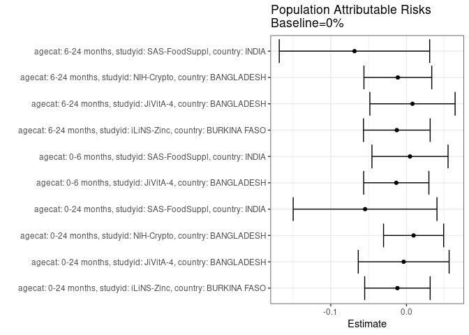

## Results Table

### Parameter: TSM

| agecat | studyid | country | intervention_level | baseline_level | estimate | ci_lower | ci_upper |
| --- | --- | --- | --- | --- | --- | --- | --- |
| 0-24 months | iLiNS-Zinc | BURKINA FASO | 0% | NA | 0.1340692 | 0.0784688 | 0.1896697 |
| 0-24 months | iLiNS-Zinc | BURKINA FASO | (0%, 5%] | NA | 0.1163300 | 0.0871826 | 0.1454775 |
| 0-24 months | iLiNS-Zinc | BURKINA FASO | >5% | NA | 0.1246164 | 0.0857981 | 0.1634347 |
| 0-24 months | JiVitA-4 | BANGLADESH | 0% | NA | 0.1650274 | 0.1037492 | 0.2263055 |
| 0-24 months | JiVitA-4 | BANGLADESH | (0%, 5%] | NA | 0.1545026 | 0.1426353 | 0.1663699 |
| 0-24 months | JiVitA-4 | BANGLADESH | >5% | NA | 0.2081814 | 0.1727272 | 0.2436355 |
| 0-24 months | NIH-Crypto | BANGLADESH | 0% | NA | 0.0842757 | 0.0404340 | 0.1281173 |
| 0-24 months | NIH-Crypto | BANGLADESH | (0%, 5%] | NA | 0.0907316 | 0.0624604 | 0.1190027 |
| 0-24 months | NIH-Crypto | BANGLADESH | >5% | NA | 0.1051262 | 0.0633646 | 0.1468878 |
| 0-24 months | SAS-FoodSuppl | INDIA | 0% | NA | 0.4255047 | 0.3186430 | 0.5323664 |
| 0-24 months | SAS-FoodSuppl | INDIA | (0%, 5%] | NA | 0.3041789 | 0.1732738 | 0.4350840 |
| 0-24 months | SAS-FoodSuppl | INDIA | >5% | NA | 0.3685892 | 0.3125428 | 0.4246356 |
| 0-6 months | JiVitA-4 | BANGLADESH | 0% | NA | 0.0400000 | -0.0045040 | 0.0845040 |
| 0-6 months | JiVitA-4 | BANGLADESH | (0%, 5%] | NA | 0.0247309 | 0.0192267 | 0.0302352 |
| 0-6 months | JiVitA-4 | BANGLADESH | >5% | NA | 0.0363636 | 0.0188137 | 0.0539135 |
| 0-6 months | SAS-FoodSuppl | INDIA | 0% | NA | 0.0722892 | 0.0165097 | 0.1280686 |
| 0-6 months | SAS-FoodSuppl | INDIA | (0%, 5%] | NA | 0.1063830 | 0.0181291 | 0.1946368 |
| 0-6 months | SAS-FoodSuppl | INDIA | >5% | NA | 0.0734266 | 0.0431606 | 0.1036925 |
| 6-24 months | iLiNS-Zinc | BURKINA FASO | 0% | NA | 0.1348622 | 0.0782438 | 0.1914806 |
| 6-24 months | iLiNS-Zinc | BURKINA FASO | (0%, 5%] | NA | 0.1168067 | 0.0877664 | 0.1458469 |
| 6-24 months | iLiNS-Zinc | BURKINA FASO | >5% | NA | 0.1243538 | 0.0844907 | 0.1642169 |
| 6-24 months | JiVitA-4 | BANGLADESH | 0% | NA | 0.1398132 | 0.0827579 | 0.1968686 |
| 6-24 months | JiVitA-4 | BANGLADESH | (0%, 5%] | NA | 0.1403968 | 0.1293580 | 0.1514356 |
| 6-24 months | JiVitA-4 | BANGLADESH | >5% | NA | 0.2017526 | 0.1657004 | 0.2378048 |
| 6-24 months | NIH-Crypto | BANGLADESH | 0% | NA | 0.0977191 | 0.0476376 | 0.1478006 |
| 6-24 months | NIH-Crypto | BANGLADESH | (0%, 5%] | NA | 0.0814244 | 0.0544725 | 0.1083763 |
| 6-24 months | NIH-Crypto | BANGLADESH | >5% | NA | 0.0871174 | 0.0480686 | 0.1261661 |
| 6-24 months | SAS-FoodSuppl | INDIA | 0% | NA | 0.4303030 | 0.3187255 | 0.5418806 |
| 6-24 months | SAS-FoodSuppl | INDIA | (0%, 5%] | NA | 0.2683098 | 0.1362064 | 0.4004133 |
| 6-24 months | SAS-FoodSuppl | INDIA | >5% | NA | 0.3573821 | 0.3008042 | 0.4139601 |

### Parameter: E(Y)

| agecat | studyid | country | intervention_level | baseline_level | estimate | ci_lower | ci_upper |
| --- | --- | --- | --- | --- | --- | --- | --- |
| 0-24 months | iLiNS-Zinc | BURKINA FASO | NA | NA | 0.1220906 | 0.0961547 | 0.1480266 |
| 0-24 months | JiVitA-4 | BANGLADESH | NA | NA | 0.1613377 | 0.1500062 | 0.1726692 |
| 0-24 months | NIH-Crypto | BANGLADESH | NA | NA | 0.0936675 | 0.0729118 | 0.1144233 |
| 0-24 months | SAS-FoodSuppl | INDIA | NA | NA | 0.3708134 | 0.3244530 | 0.4171738 |
| 0-6 months | JiVitA-4 | BANGLADESH | NA | NA | 0.0265122 | 0.0211694 | 0.0318550 |
| 0-6 months | SAS-FoodSuppl | INDIA | NA | NA | 0.0769231 | 0.0512858 | 0.1025603 |
| 6-24 months | iLiNS-Zinc | BURKINA FASO | NA | NA | 0.1220906 | 0.0961547 | 0.1480266 |
| 6-24 months | JiVitA-4 | BANGLADESH | NA | NA | 0.1477252 | 0.1371297 | 0.1583206 |
| 6-24 months | NIH-Crypto | BANGLADESH | NA | NA | 0.0863014 | 0.0659171 | 0.1066856 |
| 6-24 months | SAS-FoodSuppl | INDIA | NA | NA | 0.3615960 | 0.3145115 | 0.4086805 |

### Parameter: RR

| agecat | studyid | country | intervention_level | baseline_level | estimate | ci_lower | ci_upper |
| --- | --- | --- | --- | --- | --- | --- | --- |
| 0-24 months | iLiNS-Zinc | BURKINA FASO | 0% | 0% | 1.0000000 | 1.0000000 | 1.000000 |
| 0-24 months | iLiNS-Zinc | BURKINA FASO | (0%, 5%] | 0% | 0.8676861 | 0.5936005 | 1.268326 |
| 0-24 months | iLiNS-Zinc | BURKINA FASO | >5% | 0% | 0.9294925 | 0.5792135 | 1.491602 |
| 0-24 months | JiVitA-4 | BANGLADESH | 0% | 0% | 1.0000000 | 1.0000000 | 1.000000 |
| 0-24 months | JiVitA-4 | BANGLADESH | (0%, 5%] | 0% | 0.9362243 | 0.6402219 | 1.369081 |
| 0-24 months | JiVitA-4 | BANGLADESH | >5% | 0% | 1.2614961 | 0.8390025 | 1.896743 |
| 0-24 months | NIH-Crypto | BANGLADESH | 0% | 0% | 1.0000000 | 1.0000000 | 1.000000 |
| 0-24 months | NIH-Crypto | BANGLADESH | (0%, 5%] | 0% | 1.0766044 | 0.5869531 | 1.974735 |
| 0-24 months | NIH-Crypto | BANGLADESH | >5% | 0% | 1.2474085 | 0.6485202 | 2.399352 |
| 0-24 months | SAS-FoodSuppl | INDIA | 0% | 0% | 1.0000000 | 1.0000000 | 1.000000 |
| 0-24 months | SAS-FoodSuppl | INDIA | (0%, 5%] | 0% | 0.7148661 | 0.4343659 | 1.176505 |
| 0-24 months | SAS-FoodSuppl | INDIA | >5% | 0% | 0.8662401 | 0.6461929 | 1.161220 |
| 0-6 months | JiVitA-4 | BANGLADESH | 0% | 0% | 1.0000000 | 1.0000000 | 1.000000 |
| 0-6 months | JiVitA-4 | BANGLADESH | (0%, 5%] | 0% | 0.6182734 | 0.1981035 | 1.929607 |
| 0-6 months | JiVitA-4 | BANGLADESH | >5% | 0% | 0.9090909 | 0.2868837 | 2.880771 |
| 0-6 months | SAS-FoodSuppl | INDIA | 0% | 0% | 1.0000000 | 1.0000000 | 1.000000 |
| 0-6 months | SAS-FoodSuppl | INDIA | (0%, 5%] | 0% | 1.4716312 | 0.4739794 | 4.569182 |
| 0-6 months | SAS-FoodSuppl | INDIA | >5% | 0% | 1.0157343 | 0.4235009 | 2.436161 |
| 6-24 months | iLiNS-Zinc | BURKINA FASO | 0% | 0% | 1.0000000 | 1.0000000 | 1.000000 |
| 6-24 months | iLiNS-Zinc | BURKINA FASO | (0%, 5%] | 0% | 0.8661187 | 0.5932623 | 1.264469 |
| 6-24 months | iLiNS-Zinc | BURKINA FASO | >5% | 0% | 0.9220804 | 0.5660203 | 1.502123 |
| 6-24 months | JiVitA-4 | BANGLADESH | 0% | 0% | 1.0000000 | 1.0000000 | 1.000000 |
| 6-24 months | JiVitA-4 | BANGLADESH | (0%, 5%] | 0% | 1.0041739 | 0.6606931 | 1.526223 |
| 6-24 months | JiVitA-4 | BANGLADESH | >5% | 0% | 1.4430148 | 0.9246162 | 2.252061 |
| 6-24 months | NIH-Crypto | BANGLADESH | 0% | 0% | 1.0000000 | 1.0000000 | 1.000000 |
| 6-24 months | NIH-Crypto | BANGLADESH | (0%, 5%] | 0% | 0.8332498 | 0.4528059 | 1.533340 |
| 6-24 months | NIH-Crypto | BANGLADESH | >5% | 0% | 0.8915082 | 0.4515692 | 1.760056 |
| 6-24 months | SAS-FoodSuppl | INDIA | 0% | 0% | 1.0000000 | 1.0000000 | 1.000000 |
| 6-24 months | SAS-FoodSuppl | INDIA | (0%, 5%] | 0% | 0.6235369 | 0.3575184 | 1.087492 |
| 6-24 months | SAS-FoodSuppl | INDIA | >5% | 0% | 0.8305359 | 0.6130404 | 1.125195 |

### Parameter: PAR

| agecat | studyid | country | intervention_level | baseline_level | estimate | ci_lower | ci_upper |
| --- | --- | --- | --- | --- | --- | --- | --- |
| 0-24 months | iLiNS-Zinc | BURKINA FASO | 0% | NA | -0.0119786 | -0.0552250 | 0.0312678 |
| 0-24 months | JiVitA-4 | BANGLADESH | 0% | NA | -0.0036896 | -0.0636937 | 0.0563145 |
| 0-24 months | NIH-Crypto | BANGLADESH | 0% | NA | 0.0093919 | -0.0302996 | 0.0490834 |
| 0-24 months | SAS-FoodSuppl | INDIA | 0% | NA | -0.0546913 | -0.1496368 | 0.0402542 |
| 0-6 months | JiVitA-4 | BANGLADESH | 0% | NA | -0.0134878 | -0.0565735 | 0.0295979 |
| 0-6 months | SAS-FoodSuppl | INDIA | 0% | NA | 0.0046339 | -0.0456361 | 0.0549039 |
| 6-24 months | iLiNS-Zinc | BURKINA FASO | 0% | NA | -0.0127716 | -0.0568187 | 0.0312756 |
| 6-24 months | JiVitA-4 | BANGLADESH | 0% | NA | 0.0079119 | -0.0483866 | 0.0642105 |
| 6-24 months | NIH-Crypto | BANGLADESH | 0% | NA | -0.0114177 | -0.0561952 | 0.0333598 |
| 6-24 months | SAS-FoodSuppl | INDIA | 0% | NA | -0.0687070 | -0.1680451 | 0.0306310 |

### Parameter: PAF

| agecat | studyid | country | intervention_level | baseline_level | estimate | ci_lower | ci_upper |
| --- | --- | --- | --- | --- | --- | --- | --- |
| 0-24 months | iLiNS-Zinc | BURKINA FASO | 0% | NA | -0.0981124 | -0.5099122 | 0.2013769 |
| 0-24 months | JiVitA-4 | BANGLADESH | 0% | NA | -0.0228689 | -0.4713578 | 0.2889148 |
| 0-24 months | NIH-Crypto | BANGLADESH | 0% | NA | 0.1002681 | -0.4400816 | 0.4378669 |
| 0-24 months | SAS-FoodSuppl | INDIA | 0% | NA | -0.1474901 | -0.4345130 | 0.0821041 |
| 0-6 months | JiVitA-4 | BANGLADESH | 0% | NA | -0.5087407 | -3.3770372 | 0.4799453 |
| 0-6 months | SAS-FoodSuppl | INDIA | 0% | NA | 0.0602410 | -0.8832383 | 0.5310487 |
| 6-24 months | iLiNS-Zinc | BURKINA FASO | 0% | NA | -0.1046071 | -0.5241935 | 0.1994738 |
| 6-24 months | JiVitA-4 | BANGLADESH | 0% | NA | 0.0535585 | -0.4156006 | 0.3672287 |
| 6-24 months | NIH-Crypto | BANGLADESH | 0% | NA | -0.1323005 | -0.7895858 | 0.2835748 |
| 6-24 months | SAS-FoodSuppl | INDIA | 0% | NA | -0.1900105 | -0.4992187 | 0.0554247 |